# Assignment 8: Bootstrap Methods and Applications

Sam Johnson

Due: 03/31/2026

## **Assignment Objectives**

- Reinforce the understanding of Bootstrap sampling .
- Understand the bootstrap estimation: confidence interval and sampling distribution.

## **Policies of Using AI Tools**

**Policy on AI Tool Use**: Please adhere to the AI tool policy specified in the course syllabus. The direct copying of AI-generated content is strictly prohibited. All submitted work must reflect your own understanding; where external tools are consulted, content must be thoroughly rephrased and synthesized in your own words.

**Code Inclusion Requirement**: Any code included in your essay must be properly commented to explain the purpose and/or expected output of key code lines. Submitting AI-generated code without meaningful, student-added comments will not be accepted.

**Log-normal Distribution Revisited**

If $Y = \ln(X) \sim N(\mu, \sigma^2)$, then $X$ follows a lognormal distribution $X \sim \text{Lognormal}(\mu, \sigma^2)$. The probability density is given by

$$f(x|\mu,\sigma) = \frac{1}{x\sigma\sqrt{2\pi}} \exp\left(-\frac{(\ln x -
\mu)^2}{2\sigma^2}\right), \quad x > 0$$

After some algebra, we can express the mean and variance of the above lognormal distribution in the following

$$\begin{align}
\mathbb{E}[X] &= \exp\left(\mu + \frac{\sigma^2}{2}\right) \\
\text{Var}(X) &= [\exp(\sigma^2) - 1] \exp(2\mu + \sigma^2)
\end{align}$$

Using the relationship between normal and log-normal distribution and a sample $\{x_1, x_2, \dots, x_n\}$, the MLE estimators of $\mu$ and $\sigma^2$ are given by

$$\begin{align}
\hat{\mu} &= \frac{1}{n}\sum_{i=1}^n \ln(x_i) \\
\hat{\sigma}^2 &= \frac{1}{n}\sum_{i=1}^n (\ln(x_i) - \hat{\mu})^2
\end{align}$$

Using the plug-in principle of MLE, we have the MLE of $\mathbb{E}[X]$ and $\text{Var}(X)$ in the following

$$\boxed{\widehat{\mathbb{E}[X]} = \exp\left(\hat{\mu} +
\frac{\hat{\sigma}^2}{2}\right)}$$

**This assignment focuses on constructing various bootstrap confidence intervals of the lognormal population mean $\mathbb{E}[X]$**

## **Question: Trace Metal Concentrations in Soil**

Soil lead (Pb) concentrations (mg/kg) from 55 urban garden sites. Trace metals in environmental media typically follow lognormal distributions due to:

- Multiplicative processes controlling accumulation
- Positive constraints (concentrations cannot be negative)
- Right-skewed nature of contamination patterns

```
0.85, 1.23, 0.92, 3.45, 2.11, 1.56, 4.89, 2.34, 1.78, 6.72, 0.95, 1.34, 8.91,
2.67, 1.89, 5.43, 1.12, 3.78, 2.45, 7.65, 1.05, 1.45, 12.34, 2.89, 2.01, 4.56,
1.23, 4.32, 2.67, 9.87, 0.99, 1.56, 15.23, 3.12, 2.34, 3.89, 1.34, 5.67, 2.89,
11.45, 1.12, 1.67, 18.90, 3.45, 2.56, 3.45, 1.45, 6.78, 3.12, 14.56, 1.23, 1.78,
22.34, 3.78, 2.78
```

$$\boxed{\text{Instructions:}}$$

Assume the data follow a log-normal distribution. For each question in parts (b)–(d), begin by clearly explaining the reasoning behind your analytical approach. Then, develop your own R functions to implement three types of confidence intervals: the asymptotic interval, the percentile bootstrap interval, and the bias-corrected and accelerated (BCa) bootstrap interval. Use these functions to construct the required confidence intervals, and verify your results using the appropriate functions from the `boot` package.

You are encouraged to design a wrapper function that integrates all confidence interval methods, allowing users to select the desired method through an input argument.

$$\boxed{\text{Individual
Questions:}}$$

a). Perform 5000 bootstrap samples to estimate the bootstrap sampling distribution of $\boxed{\widehat{\mathbb{E}[X]}}$. Display the distribution using either a histogram or a kernel density plot. Comment on the shape, variability, and any notable patterns observed in the bootstrap sampling distribution.

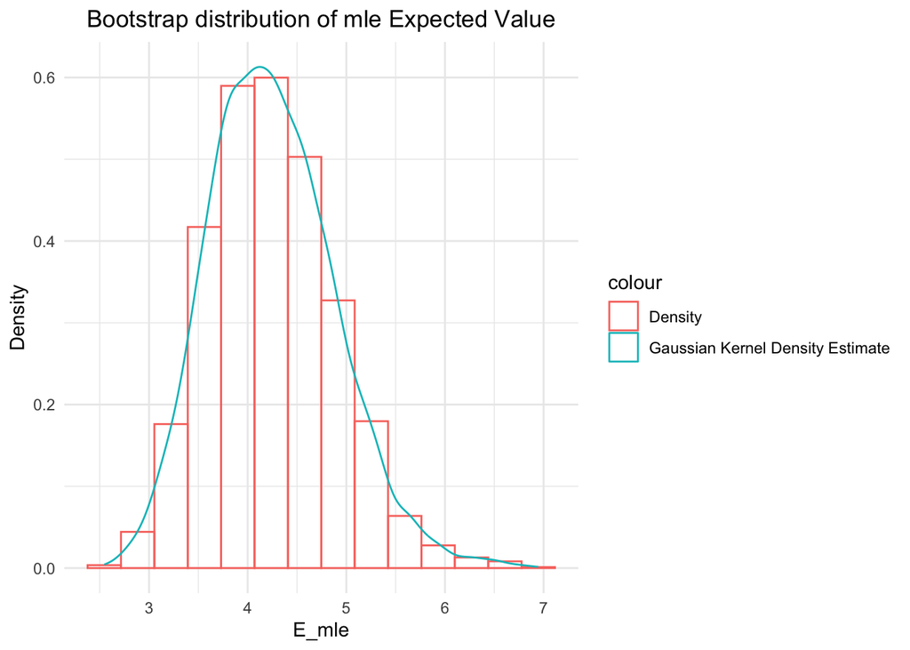

```r
X <- c(0.85, 1.23, 0.92, 3.45, 2.11, 1.56, 4.89, 2.34, 1.78, 6.72, 0.95, 1.34, 8.91,
2.67, 1.89, 5.43, 1.12, 3.78, 2.45, 7.65, 1.05, 1.45, 12.34, 2.89, 2.01, 4.56,
1.23, 4.32, 2.67, 9.87, 0.99, 1.56, 15.23, 3.12, 2.34, 3.89, 1.34, 5.67, 2.89,
11.45, 1.12, 1.67, 18.90, 3.45, 2.56, 3.45, 1.45, 6.78, 3.12, 14.56, 1.23, 1.78,
22.34, 3.78, 2.78)

mu_mle <- function(X){
  n <- length(X)
  1 / n * sum(log(X))
}

sigma_2_mle <- function(X){
  n <- length(X)
  #mu_mle only needs be called once
  mu <- mu_mle(X)
  1 / n * sum((log(X) - mu)^2)
}

E_mle <- function(X){
  exp(mu_mle(X) + sigma_2_mle(X) / 2)
}

boostrap_sample_iteration <- function(X,  estimator){
  sample_i <- sample(X, size=length(X), replace=TRUE)
  estimator(sample_i)
}

#simplify=TRUE param gives us vector as output
bootstrap_estimator_dist <- replicate(n=5000, expr=boostrap_sample_iteration(X, E_mle), simplify=TRUE)

ggplot(data=data.frame(x=bootstrap_estimator_dist), aes(x=x)) +
  geom_histogram(aes(y=after_stat(density), color="Density"), alpha=0, bins=14) +
  geom_density(aes(color="Gaussian Kernel Density Estimate")) +
  guides(alpha="none") +
  labs(title="Bootstrap distribution of mle Expected Value", x="E_mle", y="Density") +
  theme_minimal() +
  theme(plot.title = element_text(hjust = 0.5))
```

b). Construct a 95% bootstrap percentile confidence interval for $\mu_{LN} = \mathbb{E}[X]$.

```r
#there appears to be several different ways to compute a percentile from a continuous distribution
#https://en.wikipedia.org/wiki/Percentile#Calculation_methods

basic_bootstrap <- function(data, estimator, n){
  boostrap_sample_iteration <- function(X,  estimator){
    sample_i <- sample(X, size=length(X), replace=TRUE)
    estimator(sample_i)
  }

  #simplify=TRUE param gives us vector as output
  replicate(n=n, expr=boostrap_sample_iteration(data, estimator), simplify=TRUE)
}

#here we simply implement the pseudo code listed in lecture in r
percentile_ci <- function(data, statistic, B=1000, alpha=0.05){
  #boostrap_sample_iteration <- function(X,  estimator){
  #  sample_i <- sample(X, size=length(X), replace=TRUE)
  #  estimator(sample_i)
  #}

  #simplify=TRUE param gives us vector as output
  #boot_dist <- replicate(n=B, expr=boostrap_sample_iteration(data, statistic), simplify=TRUE)
  boot_dist <- basic_bootstrap(data, statistic, B)

  sorted_boot <- sort(boot_dist)

  lower_idx = floor(B * alpha/2)
  upper_idx = ceiling(B * (1 - alpha/2))

  lower = sorted_boot[lower_idx]
  upper = sorted_boot[upper_idx]

  c(lower, upper)
}
percentile_ci(X, E_mle, B=1000, alpha=0.05)
```

```
[1] 3.126928 5.603699
```

c). Construct a 95% bootstrap BCa confidence interval for $\mu_{LN} = \mathbb{E}[X]$.

```r
jackknife_sample <- function(data, statistic){
  n <- length(data)
  remove_indices <- seq(-1, by=-1, length.out=n)
  closure <- function(i){
    data[i]
  }
  sapply(remove_indices, {function(x) statistic(closure(x))})
}

bca_ci <- function(data, statistic, B=1000, alpha=0.05){
  theta_hat <- statistic(data)
  boot_dist <- basic_bootstrap(data, statistic, B)
  # Bias correction
  prop_less = sum(boot_dist < theta_hat) / B
  z0 = qnorm(prop_less)

  # Acceleration (jackknife)
  jack_vals <- jackknife_sample(data, statistic)

  theta_jack_mean = mean(jack_vals)
  numerator = sum((theta_jack_mean - jack_vals)^3)
  denominator = sum((theta_jack_mean - jack_vals)^2)
  a_hat = numerator / (6 * denominator^(3 / 2))

  # Adjusted percentiles
  z_alpha = qnorm(alpha / 2)
  z_1alpha = qnorm(1 - alpha/2)

  alpha1 = pnorm(z0 + (z0 + z_alpha)/(1 - a_hat*(z0 + z_alpha)))
  alpha2 = pnorm(z0 + (z0 + z_1alpha)/(1 - a_hat*(z0 + z_1alpha)))

  sorted_boot = sort(boot_dist)
  lower = quantile(sorted_boot, probs=alpha1)
  upper = quantile(sorted_boot, probs=alpha2)

  c(unname(lower), unname(upper))
}

bca_ci(X, E_mle, B=1000, alpha=0.05)
```

```
[1] 3.270212 5.809248
```

d). Use the Central Limit Theorem to construct a 95% asymptotic confidence interval for $\mu_{LN} = \mathbb{E}[X]$. We know
$$\mu_{LN} -
\widehat{\mu_{LN}} \sim \mathcal{N}\left(0,
\widehat{\text{Var}}(\widehat{\mu_{LN}})\right) \, \text{for large }
n$$

where
$$\mathcal{I} =
\frac{1}{\sigma^2} \begin{pmatrix}
1 & 0\\
0 & 2
\end{pmatrix}$$
and
$$\mathcal{I}_n = n \mathcal{I}$$

This means
$$\widehat{\text{Var}}(\widehat{\mu_{LN}}) = \frac{1}{n
\widehat{\sigma}^{-2}_{\text{MLE}}}$$

```r
normal_bootstrap_ci <- function(data, statistic, B=1000, alpha=0.05){
  theta_hat <- statistic(data)
  boot_dist <- basic_bootstrap(data, statistic, B)
  se_boot <- sd(boot_dist)
  z <- qnorm(1 - alpha/2)
  lower <- theta_hat - z * se_boot
  upper <- theta_hat + z * se_boot
  c(lower, upper)
}

normal_bootstrap_ci(X, E_mle)
```

```
[1] 2.997062 5.439136
```

f). Assuming the confidence intervals constructed in the previous parts are valid, evaluate their performance by comparing their widths, symmetry, stability, and sensitivity to distributional skewness. Then, provide a well‑reasoned recommendation regarding which method is most suitable for this analysis.

```r
compute_coverage <- function(ci_func, analytic_param, B, alpha=0.05, n=1000, mu_ln=0, sigma_ln=1){
  #routine to run monte carlo simulation to compute coverage probability of a
  #confidence interval
  #
  #PARAMS:
  #ci_func: function to compute confidence interval. Function
  #should take only one parameter that is the dataset. alpha=0.05 is assumed
  #
  #analytic_param: the true analytic value of the estimator. In the case of mean
  #of log normal it is exp(mu + sigma^2 / 2)
  #
  #B: the number of samples from which each confidence interval is constructed
  #
  #n: the number of a confidence intervals that are computed
  #
  #mu_ln: true log mu param of log normal
  #
  #sigma_ln: true log std of log normal

  intervals <- replicate(n, {function() ci_func(rlnorm(B, meanlog=mu_ln, sdlog=sigma_ln))}(), simplify=TRUE)
  n_within <- intervals[1,] < analytic_param & analytic_param < intervals[2,]
  sum(n_within) / n
}


E_mle_helper <- function(func){
  function(sample){
    func(sample, E_mle)
  }
}

bca_ci_E_mle <- E_mle_helper(bca_ci)
asymptotic_ci_E_mle <- E_mle_helper(normal_bootstrap_ci)
percentile_ci_E_mle <- E_mle_helper(percentile_ci)

#compare the converge at the sample size of 55
bca_coverage <- compute_coverage(bca_ci_E_mle, exp(0 + 1/2), 55, n=1000)
asymptotic_coverage <- compute_coverage(asymptotic_ci_E_mle, exp(0 + 1/2), 55, n=1000)
percentile_coverage <- compute_coverage(percentile_ci_E_mle, exp(0 + 1/2), 55, n=1000)

cat("coverage probabilities for sample size n=55\n
    bca CI: ", bca_coverage, "\n
    asymptotic CI:", asymptotic_coverage, "\n
    percentile CI:", percentile_coverage)
```

```
coverage probabilities for sample size n=55

    bca CI:  0.923

    asymptotic CI: 0.918

    percentile CI: 0.934
```